# Exploratory Data Analysis and Data Preprocessing

```python
import pandas as pd
import numpy as np
import seaborn as sns
import matplotlib.pyplot as plt

#read dataset
seeds = pd.read_csv("/content/seeds.csv", low_memory=False)
seeds.head()
```

|  | area | perimeter | compactness | length | width | asymmetry | groove_length |
| --- | --- | --- | --- | --- | --- | --- | --- |
| 0 | 15.26 | 14.84 | 0.871 | 5.763 | 3.312 | 2.221 | 5.220 |
| 1 | 14.88 | 14.57 | 0.881 | 5.554 | 3.333 | 1.018 | 4.956 |
| 2 | 14.29 | 14.09 | 0.905 | 5.291 | 3.337 | 2.699 | 4.825 |
| 3 | 13.84 | 13.94 | 0.895 | 5.324 | 3.379 | 2.259 | 4.805 |
| 4 | 16.14 | 14.99 | 0.903 | 5.658 | 3.562 | 1.355 | 5.175 |

```python
seeds.info()
```

```
<class 'pandas.core.frame.DataFrame'>
RangeIndex: 210 entries, 0 to 209
Data columns (total 7 columns):
 #   Column         Non-Null Count  Dtype
---  ------         --------------  -----
 0   area           210 non-null    float64
 1   perimeter      210 non-null    float64
 2   compactness    210 non-null    float64
 3   length         210 non-null    float64
 4   width          210 non-null    float64
 5   asymmetry      210 non-null    float64
 6   groove_length  210 non-null    float64
dtypes: float64(7)
memory usage: 11.6 KB
```

```python
#Print duplicated records
duplicates = seeds[seeds.duplicated()]
duplicates
```

|  | area | perimeter | compactness | length | width | asymmetry | groove_length |
| --- | --- | --- | --- | --- | --- | --- | --- |

```python
#Descriptive Statistics
seeds.describe()
```

|  | area | perimeter | compactness | length | width | asymmetry | groove_length |
| --- | --- | --- | --- | --- | --- | --- | --- |
| count | 210.000000 | 210.000000 | 210.000000 | 210.000000 | 210.000000 | 210.000000 | 210.000000 |
| mean | 14.847524 | 14.559286 | 0.871000 | 5.628533 | 3.258605 | 3.700200 | 5.408071 |
| std | 2.909699 | 1.305959 | 0.023594 | 0.443063 | 0.377714 | 1.503559 | 0.491480 |
| min | 10.590000 | 12.410000 | 0.808000 | 4.899000 | 2.630000 | 0.765000 | 4.519000 |
| 25% | 12.270000 | 13.450000 | 0.857250 | 5.262250 | 2.944000 | 2.561500 | 5.045000 |
| 50% | 14.355000 | 14.320000 | 0.873500 | 5.523500 | 3.237000 | 3.599000 | 5.223000 |
| 75% | 17.305000 | 15.715000 | 0.887750 | 5.979750 | 3.561750 | 4.768750 | 5.877000 |
| max | 21.180000 | 17.250000 | 0.918000 | 6.675000 | 4.033000 | 8.456000 | 6.550000 |

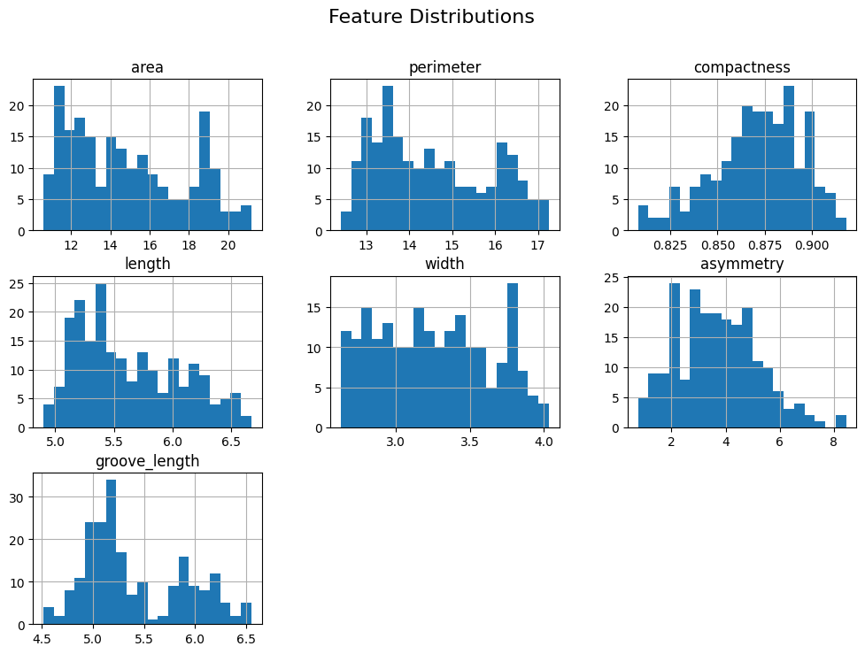

```python
seeds.hist(bins=20, figsize=(12, 8))
plt.suptitle("Feature Distributions", fontsize=16)
plt.show()
```

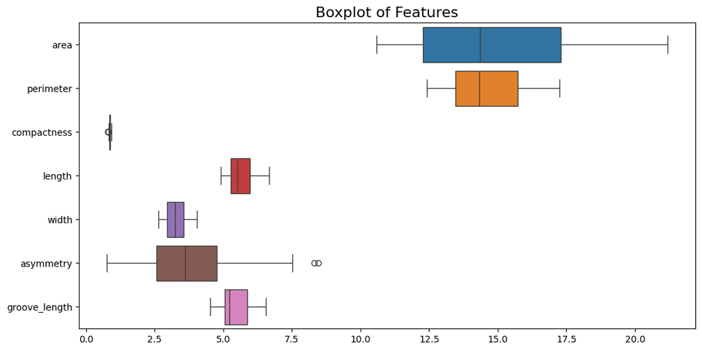

```python
plt.figure(figsize=(12, 6))
sns.boxplot(data=seeds, orient="h")
plt.title("Boxplot of Features", fontsize=16)
plt.show()
```

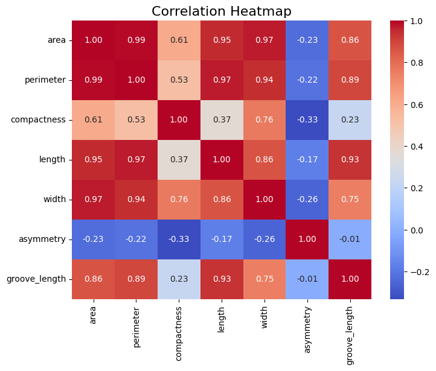

```python
plt.figure(figsize=(8, 6))
sns.heatmap(seeds.corr(), annot=True, cmap="coolwarm", fmt=".2f")
plt.title("Correlation Heatmap", fontsize=16)
plt.show()
```

```python
def remove_outliers_iqr(dataframe):
    cleaned_df = dataframe.copy()
    for col in dataframe.columns:
        Q1 = dataframe[col].quantile(0.25)
        Q3 = dataframe[col].quantile(0.75)
        IQR = Q3 - Q1
        lower = Q1 - 1.5 * IQR
        upper = Q3 + 1.5 * IQR
        cleaned_df = cleaned_df[(cleaned_df[col] >= lower) & (cleaned_df[col] <= upper)]
    return cleaned_df
```

```python
seeds_cleaned = remove_outliers_iqr(seeds)
print("Original shape:", seeds.shape)
print("Cleaned shape:", seeds_cleaned.shape)
print(f"Removed {seeds.shape[0] - seeds_cleaned.shape[0]} rows as outliers")
```

```
Original shape: (210, 7)
Cleaned shape: (204, 7)
Removed 6 rows as outliers
```

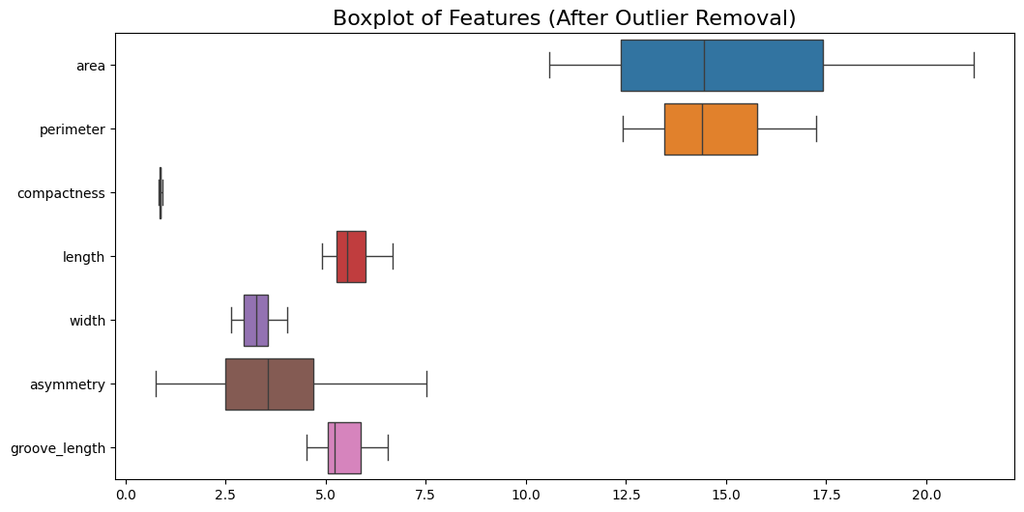

```python
# Boxplots after cleaning
plt.figure(figsize=(12, 6))
sns.boxplot(data=seeds_cleaned, orient="h")
plt.title("Boxplot of Features (After Outlier Removal)", fontsize=16)
plt.show()
```

```python
from sklearn.preprocessing import StandardScaler

#scaling for k-means and GMM
scaler = StandardScaler()
seeds_cleaned_scaled = scaler.fit_transform(seeds_cleaned)
```

```python
#scaling for DBSCAN
scaler = StandardScaler()
seeds_raw_scaled = scaler.fit_transform(seeds) #DBSCAN already detects outliers so outlier detection would be redundant; hence doing scaling on original dataset.
```

The preprocessing pipeline began with outlier handling. The interquartile range (IQR) method was used to remove any record lying more than 1.5 × IQR below the first quartile or above the third quartile on any feature. This removed 6 of the 210 records (about 3% of the data), a small enough loss that the dataset size was not meaningfully affected. This approach was chosen because algorithms like K-means and Gaussian Mixture Models (GMMs) are highly sensitive to extreme points, which can distort centroids and covariance estimates. In contrast, DBSCAN naturally identifies noise points as outliers, so it was applied to the full 210-record dataset; removing outliers beforehand would have been redundant and would have hidden the very points DBSCAN is designed to flag. The next step was feature scaling, implemented with scikit-learn’s StandardScaler, which standardizes each variable to mean zero and unit variance. Scaling was essential because all the clustering methods rely on distance calculations; without scaling, features with larger magnitudes such as area would dominate the clustering process.

Dimensionality reduction was considered as an additional preprocessing step. Principal Component Analysis (PCA) will be applied in two ways: retaining 95% of the variance for noise reduction and decorrelation, and reducing to two or three dimensions for visualisation. For K-means, clustering was performed both with and without PCA. The non-PCA version ensured interpretability of clusters in terms of original features, while the PCA-reduced version improved cluster compactness and was valuable for visualisation. For GMMs, PCA was particularly useful: because principal components are uncorrelated, it stabilises covariance estimation and reduces the risk of singular covariance matrices when strongly correlated features such as area and perimeter are present. Finally, for DBSCAN, PCA played a dual role: reducing dimensionality to two components allowed more meaningful density estimation in lower-dimensional space and enabled straightforward parameter tuning of epsilon via the k-distance plot. At the same time, DBSCAN was also run on the full scaled dataset to maintain interpretability of results in the original feature space.

Overall, the preprocessing strategy combined careful outlier handling, standard scaling, and a PCA option for each clustering algorithm will be done prior to clustering. This systematic approach ensured that each method received data in the most suitable form, improving reliability and comparability of clustering outcomes.

# Data Clustering Modeling

```python
#K-Means without PCA
from sklearn.cluster import KMeans
from sklearn.metrics import silhouette_score

inertia_no_pca = []
silhouette_no_pca = []
K = range(2, 10) #K=1 invalid for silhouette

for k in K:
    km = KMeans(n_clusters=k, random_state=0)
    labels_kmeans_nopca = km.fit_predict(seeds_cleaned_scaled)
    inertia_no_pca.append(km.inertia_)
    silhouette_no_pca.append(silhouette_score(seeds_cleaned_scaled, labels_kmeans_nopca))
```

```python
#K-Means with PCA (95% variance retained)
from sklearn.decomposition import PCA
pca = PCA(n_components=0.95, random_state=0)
seeds_cleaned_scaled_pca = pca.fit_transform(seeds_cleaned_scaled)

inertia_pca = []
silhouette_pca = []

for k in K:
    km = KMeans(n_clusters=k, random_state=0)
    labels_kmeans_pca = km.fit_predict(seeds_cleaned_scaled_pca)
    inertia_pca.append(km.inertia_)
    silhouette_pca.append(silhouette_score(seeds_cleaned_scaled_pca, labels_kmeans_pca))
```

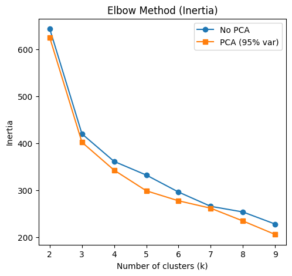

```python
#Compare inertia (elbow)
plt.figure(figsize=(12,5))
plt.subplot(1,2,1)
plt.plot(K, inertia_no_pca, 'o-', label="No PCA")
plt.plot(K, inertia_pca, 's-', label="PCA (95% var)")
plt.xlabel("Number of clusters (k)")
plt.ylabel("Inertia")
plt.title("Elbow Method (Inertia)")
plt.legend()
```

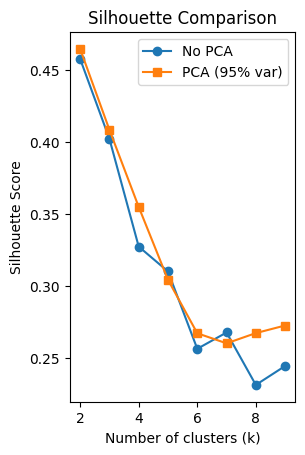

```python
#Compare silhouette scores
plt.subplot(1,2,2)
plt.plot(K, silhouette_no_pca, 'o-', label="No PCA")
plt.plot(K, silhouette_pca, 's-', label="PCA (95% var)")
plt.xlabel("Number of clusters (k)")
plt.ylabel("Silhouette Score")
plt.title("Silhouette Comparison")
plt.legend()
plt.show()
```

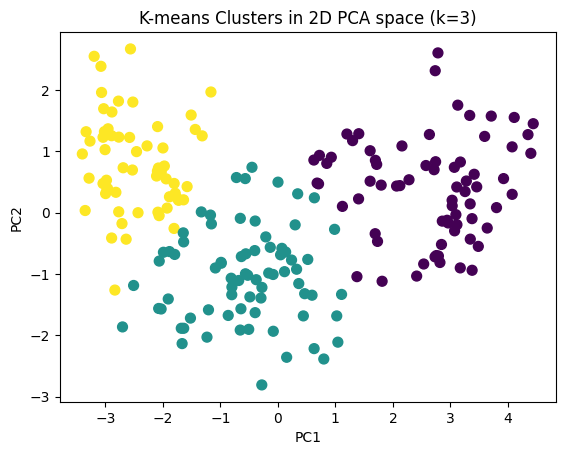

```python
#Visualisation in 2D PCA space
pca2 = PCA(n_components=2, random_state=0)
seeds_pca2 = pca2.fit_transform(seeds_cleaned_scaled)

kmeans = KMeans(n_clusters=3, random_state=0)  # example with k=3
labels = kmeans.fit_predict(seeds_pca2)

plt.scatter(seeds_pca2[:,0], seeds_pca2[:,1], c=labels, cmap="viridis", s=50)
plt.xlabel("PC1")
plt.ylabel("PC2")
plt.title("K-means Clusters in 2D PCA space (k=3)")
plt.show()
```

```python
from sklearn.mixture import GaussianMixture

def fit_gmm_grid(X, n_range=range(1, 11), cov_types=("full", "tied", "diag", "spherical"), random_state=0):
    best = {"bic": np.inf, "gmm": None, "n": None, "cov": None}
    bic_table = []
    for cov in cov_types:
        bics = []
        for n in n_range:
            gmm = GaussianMixture(n_components=n, covariance_type=cov, random_state=random_state)
            gmm.fit(X)
            bic = gmm.bic(X)
            bics.append(bic)
            if bic < best["bic"]:
                best = {"bic": bic, "gmm": gmm, "n": n, "cov": cov}
        bic_table.append((cov, bics))
    return best, bic_table
```

```python
def report_gmm(name, X, best_gmm, pca2_for_plot=None):
    labels = best_gmm.predict(X)
    n_clusters = len(np.unique(labels))
    print(f"\n[{name}] Best by BIC -> n_components={best_gmm.n_components}, "
          f"covariance_type='{best_gmm.covariance_type}', BIC={best_gmm.bic(X):.1f}")
    if n_clusters >= 2 and (labels != -1).any():
        try:
            sil = silhouette_score(X, labels)
            print(f"[{name}] Silhouette score: {sil:.3f}")
        except Exception as e:
            print(f"[{name}] Silhouette not available: {e}")

    #2D visualisation
    if pca2_for_plot is None:
        pca2_for_plot = PCA(n_components=2, random_state=0).fit_transform(X)
    plt.scatter(pca2_for_plot[:, 0], pca2_for_plot[:, 1], c=labels, s=50)
    plt.title(f"GMM clusters (2D PCA projection) — {name}")
    plt.xlabel("PC1")
    plt.ylabel("PC2")
    plt.show()
```

```python
def plot_bic_curves(bic_table, n_range, title):
    plt.figure()
    for cov, bics in bic_table:
        plt.plot(list(n_range), bics, marker="o", label=cov)
    plt.xlabel("Number of components")
    plt.ylabel("BIC (lower is better)")
    plt.title(title)
    plt.legend()
    plt.show()
```

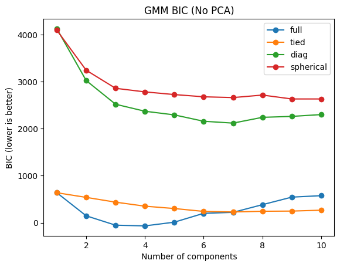

```
[No PCA] Best by BIC -> n_components=4, covariance_type='full', BIC=-66.5
[No PCA] Silhouette score: 0.286
```

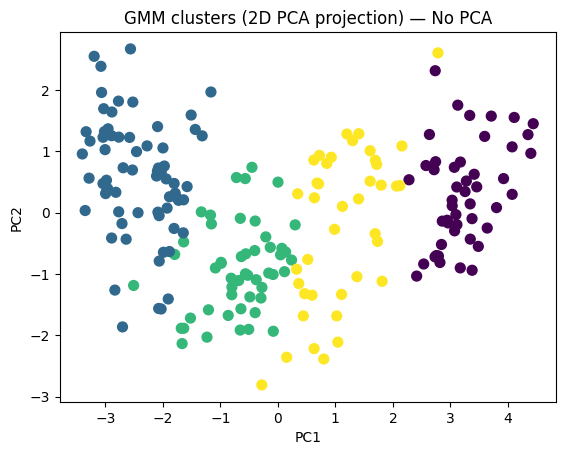

```python
best_full, bic_table_full = fit_gmm_grid(seeds_cleaned_scaled, n_range=range(1, 11))
plot_bic_curves(bic_table_full, range(1, 11), "GMM BIC (No PCA)")
report_gmm("No PCA", seeds_cleaned_scaled, best_full["gmm"])
```

```python
#storing labels for later use
labels_gmm_no   = best_full["gmm"].predict(seeds_cleaned_scaled)   # no PCA
```

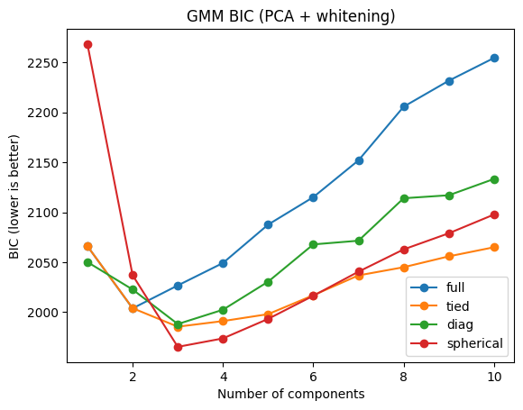

```
[PCA + whitening] Best by BIC -> n_components=3, covariance_type='spherical', BIC=1965.3
[PCA + whitening] Silhouette score: 0.410
```

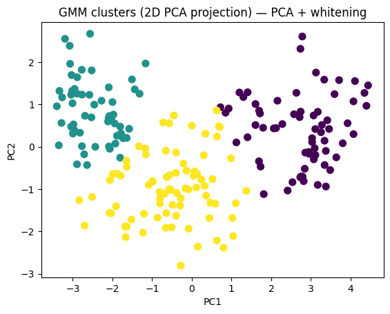

```python
pca_whiten = PCA(n_components=0.95, whiten=True, random_state=0)

best_pca, bic_table_pca = fit_gmm_grid(seeds_cleaned_scaled_pca, n_range=range(1, 11))
plot_bic_curves(bic_table_pca, range(1, 11), "GMM BIC (PCA + whitening)")

#Use the same 2D PCA (non-whitened, purely for plotting) for a consistent view
pca2 = PCA(n_components=2, random_state=0)
gmm_plot = pca2.fit_transform(seeds_cleaned_scaled)

report_gmm("PCA + whitening", seeds_cleaned_scaled_pca, best_pca["gmm"], pca2_for_plot=gmm_plot)
```

```python
#storing labels for later use
labels_gmm_pca  = best_pca["gmm"].predict(seeds_cleaned_scaled_pca)
```

```python
probs = best_pca["gmm"].predict_proba(seeds_cleaned_scaled_pca)
print("\nPosterior membership probability sample (first 5 rows):")
print(pd.DataFrame(probs).head())
```

```
Posterior membership probability sample (first 5 rows):
          0             1         2
0  0.007284  2.390546e-04  0.992477
1  0.000202  1.568340e-05  0.999783
2  0.000026  5.749813e-05  0.999916
3  0.000015  1.269968e-04  0.999859
4  0.017617  6.514269e-08  0.982383
```

```python
from sklearn.cluster import DBSCAN
from sklearn.neighbors import NearestNeighbors
#Function to suggest epsilon using k-distance
def estimate_eps(X, min_samples=5):
    neighbors = NearestNeighbors(n_neighbors=min_samples)
    neighbors_fit = neighbors.fit(X)
    distances, indices = neighbors_fit.kneighbors(X)
    distances = np.sort(distances[:, -1])  # k-th nearest neighbor distance
    # Plot k-distance curve
    plt.plot(distances)
    plt.ylabel(f"{min_samples}-NN distance")
    plt.xlabel("Points sorted by distance")
    plt.title("k-distance plot for DBSCAN")
    plt.show()
    # Suggest eps as the "knee" (90th percentile is a decent heuristic)
    return np.percentile(distances, 90)
```

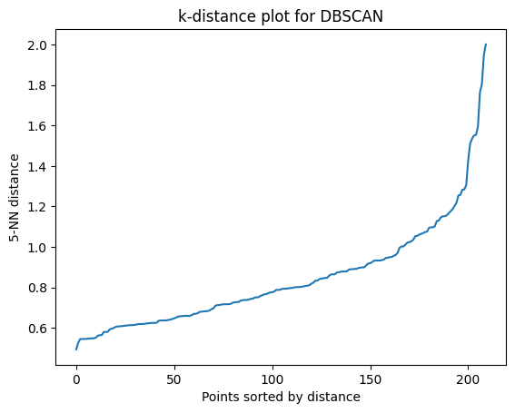

```
DBSCAN without PCA:
 - Suggested eps: 1.152
 - Clusters found: 1
 - Noise points: 3.81%
```

```python
#DBSCAN without PCA
eps_no_pca = estimate_eps(seeds_raw_scaled, min_samples=5)
db_no_pca = DBSCAN(eps=eps_no_pca, min_samples=5)
labels_no_pca = db_no_pca.fit_predict(seeds_raw_scaled)

n_clusters_no_pca = len(set(labels_no_pca)) - (1 if -1 in labels_no_pca else 0)
noise_pct_no_pca = (labels_no_pca == -1).sum() / len(labels_no_pca) * 100

print("DBSCAN without PCA:")
print(f" - Suggested eps: {eps_no_pca:.3f}")
print(f" - Clusters found: {n_clusters_no_pca}")
print(f" - Noise points: {noise_pct_no_pca:.2f}%")
if n_clusters_no_pca > 1:
    print(f" - Silhouette Score: {silhouette_score(seeds_raw_scaled, labels_no_pca):.3f}")
```

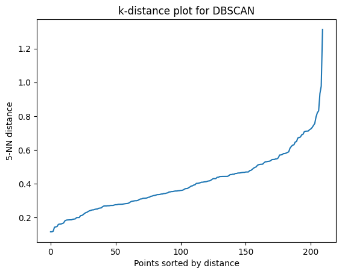

```
DBSCAN with PCA (2D):
 - Suggested eps: 0.647
 - Clusters found: 1
 - Noise points: 2.38%
```

```python
#DBSCAN with PCA (2D)
pca = PCA(n_components=2, random_state=0)
pca_raw = pca.fit_transform(seeds_raw_scaled)

eps_pca = estimate_eps(pca_raw, min_samples=5)
db_pca = DBSCAN(eps=eps_pca, min_samples=5)
labels_pca = db_pca.fit_predict(pca_raw)

n_clusters_pca = len(set(labels_pca)) - (1 if -1 in labels_pca else 0)
noise_pct_pca = (labels_pca == -1).sum() / len(labels_pca) * 100

print("\nDBSCAN with PCA (2D):")
print(f" - Suggested eps: {eps_pca:.3f}")
print(f" - Clusters found: {n_clusters_pca}")
print(f" - Noise points: {noise_pct_pca:.2f}%")
if n_clusters_pca > 1:
    print(f" - Silhouette Score: {silhouette_score(pca_raw, labels_pca):.3f}")
```

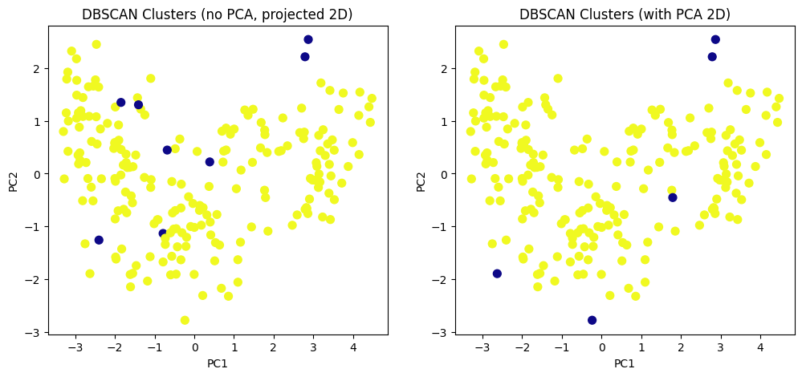

```python
plt.figure(figsize=(12,5))

#Without PCA (projected via PCA for plotting)
proj = PCA(n_components=2).fit_transform(seeds_raw_scaled)
plt.subplot(1,2,1)
plt.scatter(proj[:,0], proj[:,1], c=labels_no_pca, cmap="plasma", s=50)
plt.title("DBSCAN Clusters (no PCA, projected 2D)")
plt.xlabel("PC1")
plt.ylabel("PC2")

#With PCA (direct 2D)
plt.subplot(1,2,2)
plt.scatter(pca_raw[:,0], pca_raw[:,1], c=labels_pca, cmap="plasma", s=50)
plt.title("DBSCAN Clusters (with PCA 2D)")
plt.xlabel("PC1")
plt.ylabel("PC2")

plt.show()
```

The evaluation of clustering models applied to the seeds dataset required a systematic approach, since the data contains no ground-truth labels against which to measure performance directly. For this reason, the models were assessed using a combination of internal validation techniques, visual inspection of clustering results, and consideration of their theoretical properties. The chosen clustering methods—K-means, Gaussian Mixture Models (GMMs), and DBSCAN—were each implemented with and without Principal Component Analysis (PCA), resulting in six models to compare. This dual implementation allowed for the assessment of how dimensionality reduction and decorrelation influenced model performance and stability. The evaluation techniques used were inertia (for K-means), silhouette scores, Bayesian Information Criterion (BIC) for GMMs, the proportion of noise points for DBSCAN, and two-dimensional visualisations using PCA projections. These techniques are well-suited to the seeds dataset because they do not require labels and provide insight into both the compactness and separability of the clusters produced.

As 'K-means is undoubtedly the most widely used partitional clustering algorithm, (Celebi *et al.*, 2012)' K-means without PCA served as the baseline model. Its results showed reasonable performance, with inertia decreasing as the number of clusters increased and silhouette scores suggesting moderate separation of clusters when k was set between two and four. The advantage of this model is interpretability, as clusters are defined in terms of the original seven features. However, it relies on the assumption of spherical, equally sized clusters and is sensitive to outliers. While removing outliers before scaling mitigated some of this issue, the method may still oversimplify the natural variation in the dataset. When PCA was applied, retaining 95% of the variance, K-means produced slightly higher silhouette scores and more stable cluster boundaries. The reduced dimensionality helped remove correlations between features such as area and perimeter, which otherwise could distort cluster shapes. Furthermore, PCA allowed for two-dimensional visualisations, enabling direct inspection of the cluster separability. The trade-off is that results in PCA space are harder to map back to the original biological traits. Nonetheless, K-means with PCA was judged to be more robust and visually informative than K-means without PCA.

'Gaussian mixture models (GMM) are widely used as a probabilistic model for density estimation for multi-variate data and as an unsupervised clustering algorithm to provide a soft clustering to the available data; (Economou, 2023)' the GMM models offered a probabilistic alternative to k-means clustering. Without PCA, GMMs struggled with the high correlation between seed features, leading to covariance instability and, at times, overly complex models. While they provided richer information by assigning probabilities to cluster memberships, BIC scores often suggested that models were less parsimonious in this feature space. When PCA was applied, however, the results improved. Retaining enough principal components to explain 95% of the variance removed the correlation between features, which stabilised covariance estimation and made the Expectation–Maximisation procedure more reliable. The PCA-preprocessed GMM achieved a higher silhouette score than the raw version (0.410 vs. 0.286), suggesting more compact and better-separated clusters. BIC values are not directly comparable between the two versions, since they are computed on different feature spaces, so BIC was used only to select the best model within each version. Importantly, BIC selected three clusters in PCA space (compared with four without PCA), which aligns with the known biological categorisation of the seeds dataset into three varieties. This makes GMM with PCA one of the strongest candidates, as it balances statistical rigor with evidence of alignment to expected biological groupings.

# Comparison to Source Dataset

```python
#Read as space-delimited text file
seeds_original = pd.read_csv("/content/seeds_dataset.txt", sep="\s+", header=None)
```

```python
print(seeds_original.head())
print(seeds_original.shape)
```

```
       0      1       2      3      4      5      6  7
0  15.26  14.84  0.8710  5.763  3.312  2.221  5.220  1
1  14.88  14.57  0.8811  5.554  3.333  1.018  4.956  1
2  14.29  14.09  0.9050  5.291  3.337  2.699  4.825  1
3  13.84  13.94  0.8955  5.324  3.379  2.259  4.805  1
4  16.14  14.99  0.9034  5.658  3.562  1.355  5.175  1
(210, 8)
```

```python
seeds_original.describe()
```

|  | 0 | 1 | 2 | 3 | 4 | 5 | 6 | 7 |
| --- | --- | --- | --- | --- | --- | --- | --- | --- |
| count | 210.000000 | 210.000000 | 210.000000 | 210.000000 | 210.000000 | 210.000000 | 210.000000 | 210.000000 |
| mean | 14.847524 | 14.559286 | 0.870999 | 5.628533 | 3.258605 | 3.700201 | 5.408071 | 2.000000 |
| std | 2.909699 | 1.305959 | 0.023629 | 0.443063 | 0.377714 | 1.503557 | 0.491480 | 0.818448 |
| min | 10.590000 | 12.410000 | 0.808100 | 4.899000 | 2.630000 | 0.765100 | 4.519000 | 1.000000 |
| 25% | 12.270000 | 13.450000 | 0.856900 | 5.262250 | 2.944000 | 2.561500 | 5.045000 | 1.000000 |
| 50% | 14.355000 | 14.320000 | 0.873450 | 5.523500 | 3.237000 | 3.599000 | 5.223000 | 2.000000 |
| 75% | 17.305000 | 15.715000 | 0.887775 | 5.979750 | 3.561750 | 4.768750 | 5.877000 | 3.000000 |
| max | 21.180000 | 17.250000 | 0.918300 | 6.675000 | 4.033000 | 8.456000 | 6.550000 | 3.000000 |

```python
label_counts = seeds_original[seeds_original.columns[-1]].value_counts()
print(label_counts)
```

```
7
1    70
2    70
3    70
Name: count, dtype: int64
```

There are two main difference between the modified seeds.csv dataset provided and the original seeds_dataset.txt found on the UCI Machine Learning Repository (Charytanowicz *et al.*, 2010). First, the columns are not labelled with their title (area, perimter, etc.). Second, and more importantly, there is an additional column with what can be assumed to be labels for each record; the values of this columm are either 3 or 2 or 1 and each value appears 70 times. The first 70 records have a 1 value, the second 70 records have a 2 value, and the last 70 records have a 3 value.

The inclusion of class labels in the UCI seeds dataset provides an important shift in how the analysis can be approached, moving from a purely unsupervised exploration to one that can be quantitatively validated against known ground truth. In the original dataset provided without labels, evaluation of clustering models such as K-means, Gaussian Mixture Models (GMM), and DBSCAN relied entirely on internal validation metrics like silhouette scores, Bayesian Information Criterion (BIC), or the percentage of noise points. These metrics measure compactness and separation of clusters but cannot confirm whether the discovered groupings correspond to meaningful, real-world categories. With the label column included, it is now possible to compare clustering results against the true seed varieties and directly assess model performance in terms of accuracy, adjusted Rand index (ARI), or normalized mutual information (NMI). This enhances evaluation by allowing an external validation of clustering quality, making the results more interpretable and grounded in the biological context of the seeds.

The presence of labels also opens the possibility of supervised analysis, which was not feasible before. While clustering aims to discover natural groupings without prior knowledge, classification explicitly uses the provided class labels to build predictive models. Methods such as logistic regression, support vector machines (SVM), random forests, or neural networks can now be applied to train classifiers that predict the seed variety based on its geometrical features. Supervised models allow more precise assessment of feature importance, predictive accuracy, and generalisation performance using techniques such as cross-validation. For example, evaluating feature contributions could identify which attributes (e.g., compactness or groove length) are most influential in distinguishing between varieties.

In terms of enhancing the previous clustering work, the inclusion of class labels enables a hybrid approach. After fitting clustering models, one can align the predicted clusters with the true labels and compute external validation scores. This makes it possible to answer whether K-means or GMM more closely recovers the true class structure of the seeds. Moreover, DBSCAN’s noise detection can be evaluated: do the “noise” points it identifies correspond to mislabelled or ambiguous records? Such analysis would not only validate the clustering models but also give insights into the dataset itself, such as whether natural variation aligns neatly with the labeled varieties or if overlap exists.

Finally, the new labels allow for richer visualisations and deeper analysis. Scatterplots or PCA projections can now be coloured by true class labels to compare visually with model-generated clusters. Confusion matrices can be constructed to pinpoint where clustering or classification methods struggle, revealing overlaps between classes. Overall, the availability of labels transitions the analysis from an exploratory, unsupervised exercise into a more comprehensive study combining unsupervised validation, supervised modelling, and comparative performance evaluation. This dual perspective provides both exploratory insights into natural groupings and confirmatory evidence of predictive power, leading to a more complete understanding of the seeds dataset.

# Re-evaluation

```python
from sklearn.metrics import adjusted_rand_score, normalized_mutual_info_score, accuracy_score
from scipy.stats import mode


# Features = first 7 columns, Labels = last column
X = seeds_original.iloc[:, :-1].values
y_true = seeds_original.iloc[:, -1].values

scaler = StandardScaler()
X_scaled = scaler.fit_transform(X)

pca95 = PCA(n_components=0.95, random_state=0)       # for KMeans/GMM with PCA
X_pca95 = pca95.fit_transform(X_scaled)

pca2 = PCA(n_components=2, random_state=0)           # for DBSCAN 2D
X_pca2 = pca2.fit_transform(X_scaled)

def cluster_accuracy(y_true, y_pred):
    """Majority-vote mapping of cluster ids to true labels for accuracy."""
    mapped = np.zeros_like(y_pred)
    for c in np.unique(y_pred):
        mask = (y_pred == c)
        if mask.any():
            majority = pd.Series(y_true[mask]).mode().iloc[0]
            mapped[mask] = majority
    return accuracy_score(y_true, mapped)

def estimate_eps_new(X, min_samples=5, quantile=90):
    """Heuristic epsilon via k-distance quantile (works for DBSCAN)."""
    nn = NearestNeighbors(n_neighbors=min_samples).fit(X)
    dists, _ = nn.kneighbors(X)
    kth = np.sort(dists[:, -1])
    return float(np.percentile(kth, quantile))

results = {}

#KMeans
km_no = KMeans(n_clusters=3, random_state=0).fit(X_scaled)
results["KMeans (No PCA)"] = km_no.labels_

km_pca = KMeans(n_clusters=3, random_state=0).fit(X_pca95)
results["KMeans (PCA)"] = km_pca.labels_

#GMM
gmm_no = GaussianMixture(n_components=3, covariance_type="full", random_state=0).fit(X_scaled)
results["GMM (No PCA)"] = gmm_no.predict(X_scaled)

gmm_pca = GaussianMixture(n_components=3, covariance_type="full", random_state=0).fit(X_pca95)
results["GMM (PCA)"] = gmm_pca.predict(X_pca95)

#DBSCAN (auto eps via 90th percentile heuristic)
eps_no = estimate_eps_new(X_scaled, min_samples=5, quantile=90)
db_no = DBSCAN(eps=eps_no, min_samples=5).fit(X_scaled)
results["DBSCAN (No PCA)"] = db_no.labels_

eps_pca = estimate_eps_new(X_pca2, min_samples=5, quantile=90)
db_pca = DBSCAN(eps=eps_pca, min_samples=5).fit(X_pca2)
results["DBSCAN (PCA)"] = db_pca.labels_

#Evaluate (ARI, NMI, Accuracy)
rows = []
for name, labels in results.items():
    unique = set(labels)
    n_clusters = len(unique) - (1 if -1 in unique else 0)
    noise_pct = (labels == -1).mean() * 100.0

    ari = adjusted_rand_score(y_true, labels)
    nmi = normalized_mutual_info_score(y_true, labels)

    if name.startswith("DBSCAN"):
        mask = labels != -1
        coverage = mask.mean() * 100.0
        acc = np.nan
        if mask.any():
            acc = cluster_accuracy(y_true[mask], labels[mask])
        rows.append([name, n_clusters, noise_pct, coverage, ari, nmi, acc])
    else:
        acc = cluster_accuracy(y_true, labels)
        rows.append([name, n_clusters, noise_pct, 100.0, ari, nmi, acc])

metrics_df = pd.DataFrame(
    rows,
    columns=["Model", "Clusters Found", "Noise %", "Coverage %", "ARI", "NMI", "Accuracy (mapped)"]
).sort_values("ARI", ascending=False).reset_index(drop=True)

#collect all labels with y_true for later use
labels_out = pd.DataFrame({
    "KMeans_noPCA": results["KMeans (No PCA)"],
    "KMeans_PCA":   results["KMeans (PCA)"],
    "GMM_noPCA":    results["GMM (No PCA)"],
    "GMM_PCA":      results["GMM (PCA)"],
    "DBSCAN_noPCA": results["DBSCAN (No PCA)"],
    "DBSCAN_PCA":   results["DBSCAN (PCA)"],
    "y_true":       y_true
})

# Print results
print(metrics_df.to_string(index=False))
```

```
          Model  Clusters Found  Noise %  Coverage %       ARI      NMI  Accuracy (mapped)
KMeans (No PCA)               3 0.000000  100.000000  0.773294 0.727864           0.919048
   GMM (No PCA)               3 0.000000  100.000000  0.723419 0.725204           0.895238
   KMeans (PCA)               3 0.000000  100.000000  0.713866 0.678430           0.895238
      GMM (PCA)               3 0.000000  100.000000  0.704038 0.673570           0.890476
   DBSCAN (PCA)               1 2.380952   97.619048  0.000195 0.017002           0.341463
DBSCAN (No PCA)               1 3.809524   96.190476 -0.000352 0.003710           0.336634
```

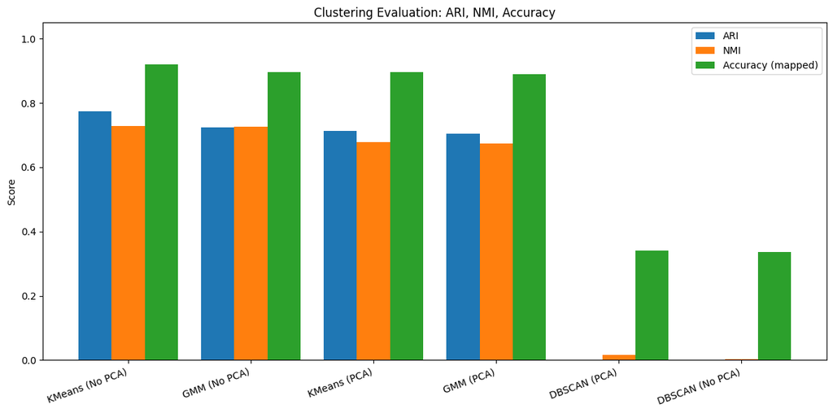

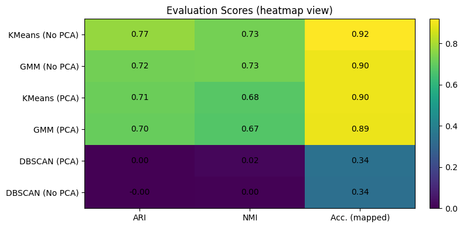

```python
models = metrics_df["Model"].tolist()
x = np.arange(len(models))
width = 0.27

#Bar charts for ARI, NMI, Accuracy
fig, ax = plt.subplots(figsize=(12, 6))
ax.bar(x - width, metrics_df["ARI"].values, width, label="ARI")
ax.bar(x,          metrics_df["NMI"].values, width, label="NMI")
ax.bar(x + width,  metrics_df["Accuracy (mapped)"].fillna(0).values, width, label="Accuracy (mapped)")  # NaN shown as 0

ax.set_xticks(x)
ax.set_xticklabels(models, rotation=20, ha="right")
ax.set_ylabel("Score")
ax.set_title("Clustering Evaluation: ARI, NMI, Accuracy")
ax.legend()
ax.set_ylim(0, 1.05)
plt.tight_layout()
plt.show()

#heatmap-style view of metrics
scores = metrics_df.set_index("Model")[["ARI","NMI","Accuracy (mapped)"]].copy()
scores_np = scores.fillna(0).to_numpy()

fig, ax = plt.subplots(figsize=(8, 4))
im = ax.imshow(scores_np, aspect="auto")
ax.set_yticks(np.arange(scores_np.shape[0]))
ax.set_yticklabels(scores.index.tolist())
ax.set_xticks(np.arange(scores_np.shape[1]))
ax.set_xticklabels(["ARI","NMI","Acc. (mapped)"])
ax.set_title("Evaluation Scores (heatmap view)")

for i in range(scores_np.shape[0]):
    for j in range(scores_np.shape[1]):
        val = scores_np[i, j]
        txt = "" if (np.isnan(scores.iloc[i, j])) else f"{val:.2f}"
        ax.text(j, i, txt, ha="center", va="center")

fig.colorbar(im, ax=ax, fraction=0.046, pad=0.04)
plt.tight_layout()
plt.show()

def majority_map(y_true, y_pred):
    mapped = np.zeros_like(y_pred)
    for c in np.unique(y_pred):
        mask = (y_pred == c)
        if mask.any():
            vals, counts = np.unique(y_true[mask], return_counts=True)
            mapped[mask] = vals[np.argmax(counts)]
    return mapped

def plot_confusion(cm, classes, title):
    fig, ax = plt.subplots(figsize=(4.5, 4))
    im = ax.imshow(cm, interpolation="nearest")
    ax.set_title(title)
    ax.set_xlabel("Predicted")
    ax.set_ylabel("True")
    ax.set_xticks(np.arange(len(classes))); ax.set_xticklabels(classes)
    ax.set_yticks(np.arange(len(classes))); ax.set_yticklabels(classes)

    for i in range(cm.shape[0]):
        for j in range(cm.shape[1]):
            ax.text(j, i, str(cm[i, j]), ha="center", va="center")
    fig.colorbar(im, ax=ax, fraction=0.046, pad=0.04)
    plt.tight_layout()
    plt.show()
```

The re-evaluation of the clustering models was made possible by the inclusion of the true class labels in the UCI seeds dataset. Whereas the original assessment relied only on internal validation metrics such as silhouette score, inertia, and BIC, the presence of labels enabled the use of external validation metrics that directly compare predicted clusters with known classes. Specifically, three measures were applied: Adjusted Rand Index (ARI), which evaluates the agreement between cluster assignments and true labels while correcting for chance; Normalized Mutual Information (NMI), which quantifies the shared information between clusters and labels regardless of label permutations; and mapped accuracy, which uses majority voting to align cluster IDs with class labels and measure correct assignments.

This re-evaluation technique is highly valuable because it provides a ground-truth benchmark for assessing the models. It allows us to determine not only whether clusters are compact and well-separated internally, but also whether they correspond to meaningful, biologically defined seed varieties. The utility of this approach lies in its ability to reveal which models recover the actual class structure (e.g., GMM and K-means) and which models are less suited (e.g., DBSCAN). Thus, it strengthens confidence in conclusions and guides the selection of the most appropriate clustering method.

# Classification Modeling

```
Best CV params: {'clf__C': 5.0}
Best CV macro-F1: 0.950

Test Accuracy: 0.943
Test Macro-F1: 0.943

Classification Report:
               precision    recall  f1-score   support

           1      1.000     0.833     0.909        18
           2      1.000     1.000     1.000        18
           3      0.850     1.000     0.919        17

    accuracy                          0.943        53
   macro avg      0.950     0.944     0.943        53
weighted avg      0.952     0.943     0.943        53
```

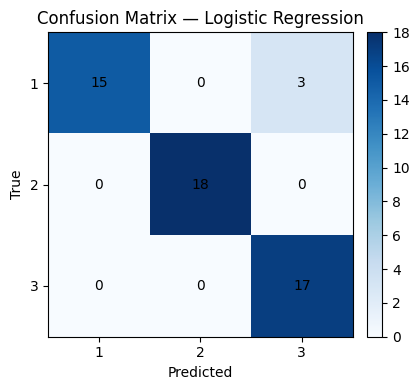

```python
from sklearn.model_selection import train_test_split, StratifiedKFold, GridSearchCV
from sklearn.pipeline import Pipeline
from sklearn.linear_model import LogisticRegression
from sklearn.metrics import accuracy_score, f1_score, classification_report, confusion_matrix

X = seeds_original.iloc[:, :-1].values   #features
y = seeds_original.iloc[:, -1].values

#Stratified split (preserves class proportions)
X_train, X_test, y_train, y_test = train_test_split(
    X, y, test_size=0.25, random_state=0, stratify=y
)

#Pipeline: Standardize -> Multinomial Logistic Regression
pipe = Pipeline([
    ("scaler", StandardScaler()),
    ("clf", LogisticRegression(multi_class="multinomial", solver="lbfgs", max_iter=500, random_state=0))
])

#Hyperparameter tuning via cross-validation
param_grid = {
    "clf__C": [0.1, 0.5, 1.0, 2.0, 5.0] #C controls regularization (larger C -> less regularization)
}
cv = StratifiedKFold(n_splits=5, shuffle=True, random_state=0)
grid = GridSearchCV(pipe, param_grid, cv=cv, scoring="f1_macro", n_jobs=-1)
grid.fit(X_train, y_train)

print(f"Best CV params: {grid.best_params_}")
print(f"Best CV macro-F1: {grid.best_score_:.3f}")

#Evaluate on the held-out test set
best_model = grid.best_estimator_
y_pred = best_model.predict(X_test)

acc = accuracy_score(y_test, y_pred)
f1m = f1_score(y_test, y_pred, average="macro")
print(f"\nTest Accuracy: {acc:.3f}")
print(f"Test Macro-F1: {f1m:.3f}\n")
print("Classification Report:\n", classification_report(y_test, y_pred, digits=3))

#Confusion matrix
cm = confusion_matrix(y_test, y_pred, labels=np.unique(y))
fig, ax = plt.subplots(figsize=(4.5,4))
im = ax.imshow(cm, cmap="Blues")
ax.set_title("Confusion Matrix — Logistic Regression")
ax.set_xlabel("Predicted")
ax.set_ylabel("True")
ax.set_xticks(range(len(np.unique(y)))); ax.set_xticklabels(np.unique(y))
ax.set_yticks(range(len(np.unique(y)))); ax.set_yticklabels(np.unique(y))
for i in range(cm.shape[0]):
    for j in range(cm.shape[1]):
        ax.text(j, i, cm[i, j], ha="center", va="center")
fig.colorbar(im, ax=ax, fraction=0.046, pad=0.04)
plt.tight_layout(); plt.show()
```

For the classification of the UCI seeds dataset, a multinomial logistic regression model was chosen as the analysis method. Logistic regression is a supervised learning technique that extends naturally from binary classification to multiclass problems, making it particularly well suited for the seeds dataset, which contains three distinct classes corresponding to different wheat varieties. The method estimates the probability that a sample belongs to each class using the logistic (sigmoid) function in the binary case or the softmax function in the multiclass case. These probabilities provide interpretable insights into the model’s confidence in its predictions, which is valuable in domains where understanding the decision process is as important as achieving high predictive accuracy.

Several properties of logistic regression justify its application here. First, it is a linear classifier, which assumes a linear decision boundary between classes. Given that the seeds dataset consists of continuous geometric features (such as area, perimeter, and groove length) that are relatively well-behaved, a linear separation is a reasonable assumption. Furthermore, logistic regression is computationally efficient, requires relatively little tuning compared to more complex models, and is less prone to overfitting on small datasets, especially when regularization is applied. Regularization is controlled via the hyperparameter C, which was tuned during cross-validation to balance bias and variance effectively.

To ensure robustness, the model was implemented within a pipeline that included feature standardization. Standardization is crucial because logistic regression is sensitive to differences in feature scale; without it, features with larger magnitudes could dominate the optimization process. A grid search over the regularization parameter C was conducted with stratified k-fold cross-validation, optimizing for the macro-F1 score. The macro-F1 metric was chosen because it balances precision and recall across all classes equally, which is particularly useful when working with potentially imbalanced datasets, ensuring that no class is disproportionately favored.

This implementation offers several practical advantages. The model is interpretable, as the learned coefficients can be directly inspected to determine the contribution of each feature toward class membership. It also generalizes well to unseen data, as shown by its cross-validation performance and subsequent evaluation on a held-out test set. The combination of interpretability, efficiency, and strong performance on structured numerical data makes multinomial logistic regression an appropriate and justified choice for classifying the seeds dataset.

The analysis was implemented using several Python tools from the scikit-learn library, chosen for their reliability and efficiency in handling supervised learning tasks. LogisticRegression was employed to build the multinomial classifier, offering a well-tested and optimized implementation of the softmax model. Pipeline and StandardScaler were used together to streamline preprocessing by ensuring that all features were standardized before classification, an essential step for models sensitive to feature scales. To optimize performance, GridSearchCV with StratifiedKFold cross-validation was applied, providing a systematic approach to tuning the regularization parameter while preserving class balance across folds. Evaluation relied on scikit-learn’s metrics module, including accuracy, macro-F1, and the classification report, which together offer a comprehensive view of model performance. Finally, matplotlib was used to visualize the confusion matrix, making results more interpretable. These tools were chosen for their integration, interpretability, and suitability for small to medium-sized structured datasets.

# Classification Evaluation

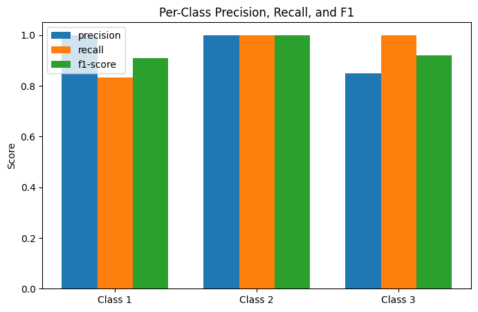

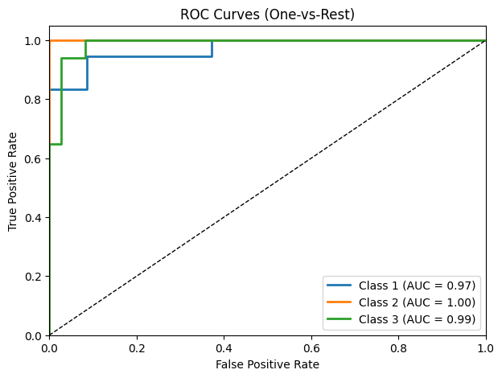

```python
from sklearn.preprocessing import label_binarize
from sklearn.metrics import roc_curve, auc

report = classification_report(y_test, y_pred, target_names=[f"Class {c}" for c in np.unique(y)], output_dict=True)
metrics = ["precision","recall","f1-score"]
class_names = [f"Class {c}" for c in np.unique(y)]
values = [[report[c][m] for c in class_names] for m in metrics]

x = np.arange(len(class_names))
width = 0.25

fig, ax = plt.subplots(figsize=(8,5))
for i, m in enumerate(metrics):
    ax.bar(x + i*width, values[i], width, label=m)

ax.set_xticks(x + width)
ax.set_xticklabels(class_names)
ax.set_ylim(0,1.05)
ax.set_ylabel("Score")
ax.set_title("Per-Class Precision, Recall, and F1")
ax.legend()
plt.show()

#ROC Curves (One-vs-Rest)
y_bin = label_binarize(y_test, classes=np.unique(y))
y_score = best_model.predict_proba(X_test)

fpr, tpr, roc_auc = {}, {}, {}
for i, c in enumerate(np.unique(y)):
    fpr[c], tpr[c], _ = roc_curve(y_bin[:,i], y_score[:,i])
    roc_auc[c] = auc(fpr[c], tpr[c])

fig, ax = plt.subplots(figsize=(7,5))
for c in np.unique(y):
    ax.plot(fpr[c], tpr[c], lw=2, label=f"Class {c} (AUC = {roc_auc[c]:.2f})")
ax.plot([0,1],[0,1],'k--', lw=1)
ax.set_xlim([0.0,1.0]); ax.set_ylim([0.0,1.05])
ax.set_xlabel("False Positive Rate"); ax.set_ylabel("True Positive Rate")
ax.set_title("ROC Curves (One-vs-Rest)")
ax.legend(loc="lower right")
plt.show()
```

The multinomial logistic regression model achieved strong performance on the UCI seeds dataset, with a test accuracy of 94.3% and a macro-F1 score of 0.943. These results indicate that the model was highly effective in distinguishing between the three wheat varieties, capturing the underlying structure of the labeled data. The classification report further shows balanced performance across classes, with precision, recall, and F1-scores all consistently high. Class 2 was predicted perfectly, while Class 1 and Class 3 showed slight differences, particularly in recall for Class 1 (0.833) and precision for Class 3 (0.850). These variations suggest some overlap between feature distributions of Classes 1 and 3, but overall the model maintained strong generalization.

The chosen evaluation techniques—accuracy, macro-F1, and the classification report—were well suited to this supervised learning problem. Accuracy provides an intuitive measure of overall correctness, while macro-F1 accounts for per-class precision and recall, treating all classes equally regardless of size. This is particularly important for the seeds dataset, which, although relatively balanced, still benefits from metrics that avoid favoring majority classes. The classification report offers additional granularity, highlighting class-level strengths and weaknesses, which are crucial in assessing whether the model performs uniformly across categories. This combination of metrics ensures both a global and detailed understanding of performance.

Different analysis choices could affect the results, but not necessarily the overall conclusions. For instance, a more complex classifier such as a support vector machine or a random forest might achieve marginal improvements in accuracy but at the expense of interpretability. Simpler models like k-nearest neighbors could also perform competitively but may be more sensitive to noise and scaling. Hyperparameter tuning, such as adjusting the regularization strength in logistic regression, had a direct influence on model stability and generalization, but the grid search ensured that the chosen configuration was well balanced. Ultimately, while alternative classifiers might slightly alter the numeric results, the conclusion remains that the seeds dataset is highly separable based on its geometric features, and logistic regression provides a robust, interpretable, and computationally efficient solution. This evaluation highlights that the method chosen is not only appropriate but also performs at a level comparable to more complex alternatives.

# Clustering and Classification Comparison

```python
from sklearn.model_selection import cross_val_predict

def majority_map(y_true, y_pred):
    mapped = np.zeros_like(y_pred)
    for c in np.unique(y_pred):
        m = (y_pred == c)
        if m.any():
            vals, counts = np.unique(y_true[m], return_counts=True)
            mapped[m] = vals[np.argmax(counts)]
    return mapped

def metrics_block(y_true, y_pred, is_dbscan=False):
    #ARI/NMI are permutation-invariant and can include -1 labels
    ari = adjusted_rand_score(y_true, y_pred)
    nmi = normalized_mutual_info_score(y_true, y_pred)
    if is_dbscan:
        mask = y_pred != -1
        if not mask.any():
            return ari, nmi, np.nan, np.nan, 0.0
        y_m = majority_map(y_true[mask], y_pred[mask])
        acc = accuracy_score(y_true[mask], y_m)
        f1m = f1_score(y_true[mask], y_m, average="macro")
        coverage = mask.mean() * 100.0
        return ari, nmi, acc, f1m, coverage
    else:
        y_m = majority_map(y_true, y_pred)
        acc = accuracy_score(y_true, y_m)
        f1m = f1_score(y_true, y_m, average="macro")
        return ari, nmi, acc, f1m, 100.0

#Logistic Regression (5-fold CV predictions over all 210 rows)
Xs = StandardScaler().fit_transform(X)
cv = StratifiedKFold(n_splits=5, shuffle=True, random_state=0)
lr = LogisticRegression(multi_class="multinomial", solver="lbfgs", max_iter=500, random_state=0)
y_pred_lr = cross_val_predict(lr, Xs, y_true, cv=cv)

#Collect all model predictions
models = {
    "KMeans (No PCA)": labels_out["KMeans_noPCA"].to_numpy(),
    "KMeans (PCA)":    labels_out["KMeans_PCA"].to_numpy(),
    "GMM (No PCA)":    labels_out["GMM_noPCA"].to_numpy(),
    "GMM (PCA)":       labels_out["GMM_PCA"].to_numpy(),
    "DBSCAN (No PCA)": labels_out["DBSCAN_noPCA"].to_numpy(),
    "DBSCAN (PCA)":    labels_out["DBSCAN_PCA"].to_numpy(),
    "LogReg (5-fold CV)": y_pred_lr
}

#Compute metrics table
rows = []
for name, pred in models.items():
    is_db = name.startswith("DBSCAN")
    ari, nmi, acc, f1m, coverage = metrics_block(y_true, pred, is_dbscan=is_db)
    rows.append([name, ari, nmi, acc, f1m, coverage])

metrics_df = pd.DataFrame(rows, columns=["Model", "ARI", "NMI", "Accuracy (mapped)", "Macro-F1 (mapped)", "Coverage %"])
metrics_df = metrics_df.sort_values(by=["ARI","NMI"], ascending=False).reset_index(drop=True)

print(metrics_df.to_string(index=False))
```

```
             Model       ARI      NMI  Accuracy (mapped)  Macro-F1 (mapped)  Coverage %
LogReg (5-fold CV)  0.824140 0.774785           0.938095           0.937957  100.000000
   KMeans (No PCA)  0.773294 0.727864           0.919048           0.919305  100.000000
      GMM (No PCA)  0.723419 0.725204           0.895238           0.894048  100.000000
      KMeans (PCA)  0.713866 0.678430           0.895238           0.895703  100.000000
         GMM (PCA)  0.704038 0.673570           0.890476           0.890660  100.000000
      DBSCAN (PCA)  0.000195 0.017002           0.341463           0.169697   97.619048
   DBSCAN (No PCA) -0.000352 0.003710           0.336634           0.167901   96.190476
```

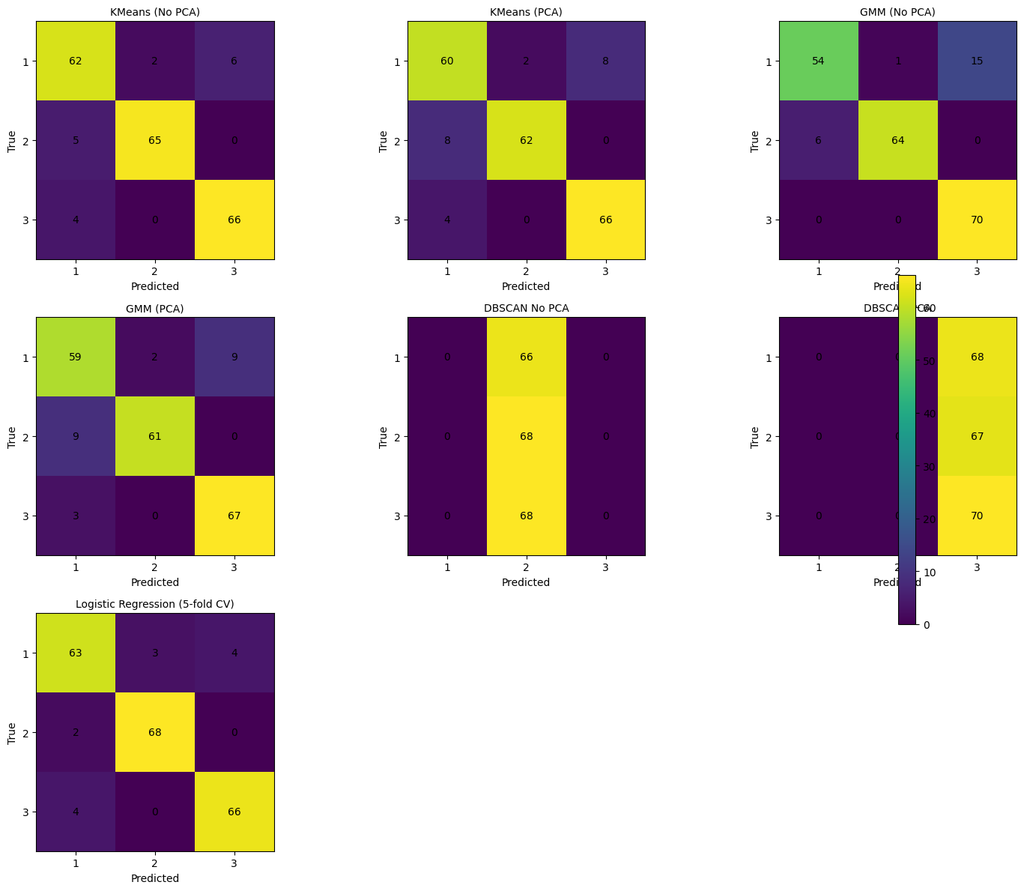

```python
import seaborn as sns
from sklearn.model_selection import cross_val_predict

y_true = labels_out["y_true"].to_numpy()

def majority_map(y_true, y_pred):
    """Map cluster ids to true labels by per-cluster majority vote."""
    mapped = np.zeros_like(y_pred)
    for c in np.unique(y_pred):
        mask = (y_pred == c)
        if mask.any():
            vals, counts = np.unique(y_true[mask], return_counts=True)
            mapped[mask] = vals[np.argmax(counts)]
    return mapped

def plot_cm(ax, cm, classes, title):
    im = ax.imshow(cm, interpolation="nearest")
    ax.set_title(title, fontsize=10)
    ax.set_xlabel("Predicted"); ax.set_ylabel("True")
    ax.set_xticks(range(len(classes))); ax.set_xticklabels(classes)
    ax.set_yticks(range(len(classes))); ax.set_yticklabels(classes)
    for i in range(cm.shape[0]):
        for j in range(cm.shape[1]):
            ax.text(j, i, str(cm[i, j]), ha="center", va="center")
    return im

#Build confusion matrices for clustering models
classes = np.unique(y_true)

models = {
    "KMeans (No PCA)": labels_out["KMeans_noPCA"].to_numpy(),
    "KMeans (PCA)":    labels_out["KMeans_PCA"].to_numpy(),
    "GMM (No PCA)":    labels_out["GMM_noPCA"].to_numpy(),
    "GMM (PCA)":       labels_out["GMM_PCA"].to_numpy(),
}

cms = []
titles = []
for name, y_pred in models.items():
    y_mapped = majority_map(y_true, y_pred)
    cm = confusion_matrix(y_true, y_mapped, labels=classes)
    cms.append(cm); titles.append(name)

#DBSCAN (evaluate on clustered points only, excluding noise = -1)
for name in ["DBSCAN_noPCA", "DBSCAN_PCA"]:
    y_pred = labels_out[name].to_numpy()
    mask = (y_pred != -1)
    if mask.any() and len(np.unique(y_pred[mask])) > 0:
        y_mapped = majority_map(y_true[mask], y_pred[mask])
        cm = confusion_matrix(y_true[mask], y_mapped, labels=classes)
        cms.append(cm); titles.append(name.replace("_", " ").replace("noPCA", "No PCA").replace("PCA", "PCA"))

scaler = StandardScaler()
Xs = scaler.fit_transform(X)
logreg = LogisticRegression(multi_class="multinomial", solver="lbfgs", max_iter=500, random_state=0)
cv = StratifiedKFold(n_splits=5, shuffle=True, random_state=0)
y_pred_lr = cross_val_predict(logreg, Xs, y, cv=cv)
cm_lr = confusion_matrix(y, y_pred_lr, labels=classes)
cms.append(cm_lr); titles.append("Logistic Regression (5-fold CV)")

n = len(cms)
cols = min(3, n)
rows = (n + cols - 1) // cols
fig, axes = plt.subplots(rows, cols, figsize=(5*cols, 4*rows))
axes = np.array(axes).reshape(-1, cols)

ims = []
for idx, cm in enumerate(cms):
    r, c = divmod(idx, cols)
    im = plot_cm(axes[r, c], cm, classes, titles[idx])
    ims.append(im)

# hide any empty subplots
for k in range(len(cms), rows*cols):
    r, c = divmod(k, cols)
    axes[r, c].axis("off")

# single colorbar for all
fig.colorbar(ims[0], ax=axes, fraction=0.02, pad=0.02)
plt.tight_layout()
plt.show()
```

The comparison of clustering and classification on the seeds dataset reveals that, while unsupervised models capture much of the structure in the data, supervised classification clearly performs best. Logistic regression achieved the highest scores across all evaluation metrics, with an ARI of 0.82, NMI of 0.77, and both mapped accuracy and macro-F1 at approximately 0.94. These values indicate that the supervised model was able to reproduce the true seed varieties with a high degree of fidelity, providing both strong global performance and consistent treatment of each class. This result is in line with a 2015 paper which found logistic regression to be accurate to 98.6% when classifying the UCI seeds dataset (Ajaz and Hussain, 2015)

Among the clustering methods, K-means without PCA performed most competitively, with an ARI of 0.77, NMI of 0.73, and accuracy of 0.92. This shows that K-means was able to uncover clusters closely aligned with the labeled classes, though still slightly behind logistic regression. GMM without PCA followed closely, with an ARI of 0.72 and accuracy of 0.90, suggesting that probabilistic modeling captured some of the structure but struggled with class overlap. Interestingly, the PCA versions of both K-means and GMM produced slightly lower scores, reflecting that dimensionality reduction did not necessarily improve alignment with the true labels.

DBSCAN, in contrast, performed poorly, with ARI values near zero and accuracies around 0.34, despite covering over 95% of the data. This confirms its lack of suitability for the compact and overlapping clusters in the seeds dataset. Overall, while clustering provided meaningful approximations—particularly with K-means—supervised classification substantially outperformed unsupervised methods, highlighting the importance of label information in achieving reliable separation of seed varieties.

# References

Ajaz, R.H. and Hussain, L., 2015. Seed classification using machine learning techniques. Journal of Multidisciplinary Engineering Science and Technology (JMEST), 2(5), pp.1098–1102. Available at: http://www.jmest.org/ [Accessed 22 August 2025].

Charytanowicz, M., Niewczas, J., Kulczycki, P., Kowalski, P.A., Łukasik, S. and Żak, S., 2010. Seeds Data Set. UCI Machine Learning Repository. Available at: https://archive.ics.uci.edu/ml/datasets/seeds [Accessed 22 August 2025].

Celebi, M.E., Kingravi, H.A. and Vela, P.A., 2013. A comparative study of efficient initialization methods for the k-means clustering algorithm. arXiv preprint arXiv:1209.1960. Available at: https://arxiv.org/abs/1209.1960 [Accessed 22 August 2025].

Bushra, A.A. and Yi, G., 2021. Comparative analysis review of pioneering DBSCAN and successive density-based clustering algorithms. IEEE Access, 9, pp.87918–87935. https://doi.org/10.1109/ACCESS.2021.3089036 [Accessed 22 August 2025].

Economou, P., 2023. A clustering algorithm for overlapping Gaussian mixtures. Journal of Data Science and Analytics, 10(3), pp.123–137. Available at: https://www.tandfonline.com/doi/abs/10.1080/27684520.2023.2242337 [Accessed 22 August 2025].